# Rossmann Store Sales Forecast

Rossmann 是德国最大的日化品连锁超市，遍布欧洲多个国家

```python
#导入需要的包
import numpy as np
import pandas as pd
from pandas import Series,DataFrame
import seaborn as sns
import matplotlib.pyplot as plt



%matplotlib inline
```

# 读入数据

```python
df_train = pd.read_csv("data/train.csv")
df_test = pd.read_csv("data/test.csv")
df_store = pd.read_csv("data/store.csv")

df_train.head()
#train.describe()
#test.describe()
#store.describe()
```

|  | Store | DayOfWeek | Date | Sales | Customers | Open | Promo | StateHoliday | SchoolHoliday |
| --- | --- | --- | --- | --- | --- | --- | --- | --- | --- |
| 0 | 1 | 5 | 2015-07-31 | 5263 | 555 | 1 | 1 | 0 | 1 |
| 1 | 2 | 5 | 2015-07-31 | 6064 | 625 | 1 | 1 | 0 | 1 |
| 2 | 3 | 5 | 2015-07-31 | 8314 | 821 | 1 | 1 | 0 | 1 |
| 3 | 4 | 5 | 2015-07-31 | 13995 | 1498 | 1 | 1 | 0 | 1 |
| 4 | 5 | 5 | 2015-07-31 | 4822 | 559 | 1 | 1 | 0 | 1 |

# 观察分析数据

```python
df_train.columns
```

```
Index(['Store', 'DayOfWeek', 'Date', 'Sales', 'Customers', 'Open', 'Promo',
       'StateHoliday', 'SchoolHoliday'],
      dtype='object')
```

- Store: 门店编号
- DayOfWeek:一周的第几天，如5，代表周五
- Date： 日期
- Sales: 销售额
- Customers:顾客数量
- Open: 开业状态，1代表开业，0代表关店
- Promo: 有无促销活动，1代表有促销，0代表无促销
- StateHoliday：是否是州假日，a=公共假日，b=复活节，c=圣诞节，0=不是州假日
- SchoolHoliday:是否是学校假日,0代表不是，1代表是

```python
#增加所在的月份、所在周数 和平均每个客户的花费
df_train['Month']=pd.to_datetime(df_train['Date']).dt.month
df_train['WeekOfYear']=pd.to_datetime(df_train['Date']).dt.weekofyear
df_train['SalesPerCustomer'] = df_train.Sales / df_train.Customers
df_train.head()
```

|  | Store | DayOfWeek | Date | Sales | Customers | Open | Promo | StateHoliday | SchoolHoliday | Month | WeekOfYear | SalesPerCustomer |
| --- | --- | --- | --- | --- | --- | --- | --- | --- | --- | --- | --- | --- |
| 0 | 1 | 5 | 2015-07-31 | 5263 | 555 | 1 | 1 | 0 | 1 | 7 | 31 | 9.482883 |
| 1 | 2 | 5 | 2015-07-31 | 6064 | 625 | 1 | 1 | 0 | 1 | 7 | 31 | 9.702400 |
| 2 | 3 | 5 | 2015-07-31 | 8314 | 821 | 1 | 1 | 0 | 1 | 7 | 31 | 10.126675 |
| 3 | 4 | 5 | 2015-07-31 | 13995 | 1498 | 1 | 1 | 0 | 1 | 7 | 31 | 9.342457 |
| 4 | 5 | 5 | 2015-07-31 | 4822 | 559 | 1 | 1 | 0 | 1 | 7 | 31 | 8.626118 |

```python
df_store.head()
```

|  | Store | StoreType | Assortment | CompetitionDistance | CompetitionOpenSinceMonth | CompetitionOpenSinceYear | Promo2 | Promo2SinceWeek | Promo2SinceYear | PromoInterval |
| --- | --- | --- | --- | --- | --- | --- | --- | --- | --- | --- |
| 0 | 1 | c | a | 1270.0 | 9.0 | 2008.0 | 0 | NaN | NaN | NaN |
| 1 | 2 | a | a | 570.0 | 11.0 | 2007.0 | 1 | 13.0 | 2010.0 | Jan,Apr,Jul,Oct |
| 2 | 3 | a | a | 14130.0 | 12.0 | 2006.0 | 1 | 14.0 | 2011.0 | Jan,Apr,Jul,Oct |
| 3 | 4 | c | c | 620.0 | 9.0 | 2009.0 | 0 | NaN | NaN | NaN |
| 4 | 5 | a | a | 29910.0 | 4.0 | 2015.0 | 0 | NaN | NaN | NaN |

- Store ：门店编号
- StoreType:门店类型,a，b，c，d
- Assortment: 描述分类级别：a =基本，b =额外，c =扩展
- CompetitionDistance:与最近竞争对手门店的距离
- CompetitionOpenSinceMonth:最近竞争对手开店的月份
- CompetitionOpenSinceYear: 最近竞争对手开店年份
- Promo2:有无连续促销活动，0代表没有，1代表有
- Promo2SinceWeek:描述商店开始参与连续促销的日历周
- Promo2SinceYear:描述商店开始参与连续促销的年份
- PromoInterval:描述Promo2启动的连续间隔，命名重新开始促销的月份。例如，“2月，5月，8月，11月”意味着每一轮在该商店的任何给定年份的2月，5月，8月和11月开始

```python
df_test.head()
```

|  | Id | Store | DayOfWeek | Date | Open | Promo | StateHoliday | SchoolHoliday |
| --- | --- | --- | --- | --- | --- | --- | --- | --- |
| 0 | 1 | 1 | 4 | 2015-09-17 | 1.0 | 1 | 0 | 0 |
| 1 | 2 | 3 | 4 | 2015-09-17 | 1.0 | 1 | 0 | 0 |
| 2 | 3 | 7 | 4 | 2015-09-17 | 1.0 | 1 | 0 | 0 |
| 3 | 4 | 8 | 4 | 2015-09-17 | 1.0 | 1 | 0 | 0 |
| 4 | 5 | 9 | 4 | 2015-09-17 | 1.0 | 1 | 0 | 0 |

查看训练集中是否存Open状态为营业，但销售额为0的店

```python
#看一下是否存在开店状态下，销售额为0的情况
df_train[(df_train.Open==1) & (df_train.Sales==0)].shape[0]
#df_train[df_train.Sales==0]
#df_train[df_train.Open==0]
```

```
54
```

```python
df_train[(df_train.Open==0) & (df_train.Sales>0)].shape[0]
```

```
0
```

事实上是不存在关店状态下销售额大于0这样的情况

```python
#查看训练集、测试集和store中数据缺失情况
display(df_train.isnull().sum(),df_test.isnull().sum(),df_store.isnull().sum())
```

```
Store                    0
DayOfWeek                0
Date                     0
Sales                    0
Customers                0
Open                     0
Promo                    0
StateHoliday             0
SchoolHoliday            0
Month                    0
WeekOfYear               0
SalesPerCustomer    172869
dtype: int64
```

```
Id                0
Store             0
DayOfWeek         0
Date              0
Open             11
Promo             0
StateHoliday      0
SchoolHoliday     0
dtype: int64
```

```
Store                          0
StoreType                      0
Assortment                     0
CompetitionDistance            3
CompetitionOpenSinceMonth    354
CompetitionOpenSinceYear     354
Promo2                         0
Promo2SinceWeek              544
Promo2SinceYear              544
PromoInterval                544
dtype: int64
```

```python
#看一下df_store数据集中CompetitionDistance为空的具体情况
df_store[pd.isnull(df_store.CompetitionDistance)]
```

|  | Store | StoreType | Assortment | CompetitionDistance | CompetitionOpenSinceMonth | CompetitionOpenSinceYear | Promo2 | Promo2SinceWeek | Promo2SinceYear | PromoInterval |
| --- | --- | --- | --- | --- | --- | --- | --- | --- | --- | --- |
| 290 | 291 | d | a | NaN | NaN | NaN | 0 | NaN | NaN | NaN |
| 621 | 622 | a | c | NaN | NaN | NaN | 0 | NaN | NaN | NaN |
| 878 | 879 | d | a | NaN | NaN | NaN | 1 | 5.0 | 2013.0 | Feb,May,Aug,Nov |

```python
df_store[pd.isnull(df_store.CompetitionOpenSinceMonth)]
```

|  | Store | StoreType | Assortment | CompetitionDistance | CompetitionOpenSinceMonth | CompetitionOpenSinceYear | Promo2 | Promo2SinceWeek | Promo2SinceYear | PromoInterval |
| --- | --- | --- | --- | --- | --- | --- | --- | --- | --- | --- |
| 11 | 12 | a | c | 1070.0 | NaN | NaN | 1 | 13.0 | 2010.0 | Jan,Apr,Jul,Oct |
| 12 | 13 | d | a | 310.0 | NaN | NaN | 1 | 45.0 | 2009.0 | Feb,May,Aug,Nov |
| 15 | 16 | a | c | 3270.0 | NaN | NaN | 0 | NaN | NaN | NaN |
| 18 | 19 | a | c | 3240.0 | NaN | NaN | 1 | 22.0 | 2011.0 | Mar,Jun,Sept,Dec |
| 21 | 22 | a | a | 1040.0 | NaN | NaN | 1 | 22.0 | 2012.0 | Jan,Apr,Jul,Oct |
| 25 | 26 | d | a | 2300.0 | NaN | NaN | 0 | NaN | NaN | NaN |
| 28 | 29 | d | c | 2170.0 | NaN | NaN | 0 | NaN | NaN | NaN |
| 31 | 32 | a | a | 2910.0 | NaN | NaN | 1 | 45.0 | 2009.0 | Feb,May,Aug,Nov |
| 39 | 40 | a | a | 180.0 | NaN | NaN | 1 | 45.0 | 2009.0 | Feb,May,Aug,Nov |
| 40 | 41 | d | c | 1180.0 | NaN | NaN | 1 | 31.0 | 2013.0 | Jan,Apr,Jul,Oct |
| 41 | 42 | a | c | 290.0 | NaN | NaN | 1 | 40.0 | 2011.0 | Jan,Apr,Jul,Oct |
| 42 | 43 | d | a | 4880.0 | NaN | NaN | 1 | 37.0 | 2009.0 | Jan,Apr,Jul,Oct |
| 61 | 62 | a | a | 2050.0 | NaN | NaN | 0 | NaN | NaN | NaN |
| 63 | 64 | d | c | 22560.0 | NaN | NaN | 1 | 14.0 | 2013.0 | Jan,Apr,Jul,Oct |
| 65 | 66 | d | a | 7660.0 | NaN | NaN | 1 | 37.0 | 2009.0 | Jan,Apr,Jul,Oct |
| 67 | 68 | a | c | 250.0 | NaN | NaN | 1 | 35.0 | 2012.0 | Mar,Jun,Sept,Dec |
| 68 | 69 | c | c | 1130.0 | NaN | NaN | 1 | 40.0 | 2011.0 | Jan,Apr,Jul,Oct |
| 69 | 70 | c | c | 4840.0 | NaN | NaN | 0 | NaN | NaN | NaN |
| 73 | 74 | a | a | 330.0 | NaN | NaN | 0 | NaN | NaN | NaN |
| 78 | 79 | a | a | 3320.0 | NaN | NaN | 0 | NaN | NaN | NaN |
| 79 | 80 | d | a | 7910.0 | NaN | NaN | 0 | NaN | NaN | NaN |
| 82 | 83 | a | a | 2710.0 | NaN | NaN | 0 | NaN | NaN | NaN |
| 90 | 91 | c | a | 2410.0 | NaN | NaN | 1 | 35.0 | 2011.0 | Jan,Apr,Jul,Oct |
| 91 | 92 | c | a | 240.0 | NaN | NaN | 1 | 45.0 | 2009.0 | Feb,May,Aug,Nov |
| 92 | 93 | a | a | 16690.0 | NaN | NaN | 1 | 14.0 | 2011.0 | Jan,Apr,Jul,Oct |
| 93 | 94 | d | c | 14620.0 | NaN | NaN | 0 | NaN | NaN | NaN |
| 96 | 97 | d | c | 8980.0 | NaN | NaN | 0 | NaN | NaN | NaN |
| 99 | 100 | d | a | 17930.0 | NaN | NaN | 0 | NaN | NaN | NaN |
| 100 | 101 | d | c | 2440.0 | NaN | NaN | 1 | 22.0 | 2012.0 | Mar,Jun,Sept,Dec |
| 104 | 105 | a | c | 6190.0 | NaN | NaN | 1 | 23.0 | 2013.0 | Mar,Jun,Sept,Dec |
| ... | ... | ... | ... | ... | ... | ... | ... | ... | ... | ... |
| 1035 | 1036 | d | c | 9560.0 | NaN | NaN | 1 | 36.0 | 2013.0 | Jan,Apr,Jul,Oct |
| 1036 | 1037 | a | c | 150.0 | NaN | NaN | 0 | NaN | NaN | NaN |
| 1041 | 1042 | a | a | 3440.0 | NaN | NaN | 1 | 31.0 | 2013.0 | Feb,May,Aug,Nov |
| 1046 | 1047 | a | a | 3750.0 | NaN | NaN | 1 | 45.0 | 2009.0 | Feb,May,Aug,Nov |
| 1051 | 1052 | a | c | 5080.0 | NaN | NaN | 1 | 31.0 | 2013.0 | Feb,May,Aug,Nov |
| 1053 | 1054 | a | c | 13190.0 | NaN | NaN | 1 | 45.0 | 2013.0 | Feb,May,Aug,Nov |
| 1055 | 1056 | d | c | 5350.0 | NaN | NaN | 1 | 40.0 | 2012.0 | Jan,Apr,Jul,Oct |
| 1057 | 1058 | a | c | 180.0 | NaN | NaN | 1 | 35.0 | 2010.0 | Mar,Jun,Sept,Dec |
| 1059 | 1060 | a | c | 3430.0 | NaN | NaN | 1 | 31.0 | 2013.0 | Feb,May,Aug,Nov |
| 1060 | 1061 | d | c | 8110.0 | NaN | NaN | 0 | NaN | NaN | NaN |
| 1062 | 1063 | a | c | 6250.0 | NaN | NaN | 0 | NaN | NaN | NaN |
| 1063 | 1064 | a | c | 420.0 | NaN | NaN | 0 | NaN | NaN | NaN |
| 1064 | 1065 | a | a | 1290.0 | NaN | NaN | 1 | 35.0 | 2011.0 | Mar,Jun,Sept,Dec |
| 1065 | 1066 | a | a | 3350.0 | NaN | NaN | 0 | NaN | NaN | NaN |
| 1067 | 1068 | d | c | 5010.0 | NaN | NaN | 1 | 5.0 | 2013.0 | Jan,Apr,Jul,Oct |
| 1068 | 1069 | a | c | 18050.0 | NaN | NaN | 1 | 14.0 | 2011.0 | Jan,Apr,Jul,Oct |
| 1072 | 1073 | a | c | 1710.0 | NaN | NaN | 1 | 44.0 | 2012.0 | Jan,Apr,Jul,Oct |
| 1075 | 1076 | a | c | 90.0 | NaN | NaN | 1 | 1.0 | 2013.0 | Jan,Apr,Jul,Oct |
| 1077 | 1078 | d | c | 670.0 | NaN | NaN | 1 | 40.0 | 2011.0 | Jan,Apr,Jul,Oct |
| 1078 | 1079 | a | a | 16680.0 | NaN | NaN | 1 | 37.0 | 2009.0 | Jan,Apr,Jul,Oct |
| 1079 | 1080 | a | a | 2410.0 | NaN | NaN | 1 | 40.0 | 2014.0 | Jan,Apr,Jul,Oct |
| 1082 | 1083 | d | c | 11540.0 | NaN | NaN | 1 | 5.0 | 2013.0 | Feb,May,Aug,Nov |
| 1083 | 1084 | a | a | 190.0 | NaN | NaN | 1 | 13.0 | 2010.0 | Jan,Apr,Jul,Oct |
| 1089 | 1090 | a | a | 330.0 | NaN | NaN | 1 | 14.0 | 2011.0 | Jan,Apr,Jul,Oct |
| 1090 | 1091 | a | c | 9990.0 | NaN | NaN | 0 | NaN | NaN | NaN |
| 1095 | 1096 | a | c | 1130.0 | NaN | NaN | 1 | 10.0 | 2014.0 | Mar,Jun,Sept,Dec |
| 1099 | 1100 | a | a | 540.0 | NaN | NaN | 1 | 14.0 | 2011.0 | Jan,Apr,Jul,Oct |
| 1112 | 1113 | a | c | 9260.0 | NaN | NaN | 0 | NaN | NaN | NaN |
| 1113 | 1114 | a | c | 870.0 | NaN | NaN | 0 | NaN | NaN | NaN |
| 1114 | 1115 | d | c | 5350.0 | NaN | NaN | 1 | 22.0 | 2012.0 | Mar,Jun,Sept,Dec |

354 rows × 10 columns

从上面数据来看，df_store 数据集中291、622和879 这三家店附近没有竞争对手，因此与竞争对手相关的指标(CompetitionOpenSinceMonth、CompetitionOpenSinceYear)也是空值，这是符合逻辑的，为了便于处理，后续的步骤中将会对着三家的缺失值进行补全。但是从另一方面来看CompetitionOpenSinceMonth（或CompetitionOpenSinceMonth）是空值的，竞争对手CompetitionDistance不一定为空

```python
#df_store[df_store[df_store.Promo2==0 ]][['Promo2SinceWeek','Promo2SinceYear','PromoInterval']]
df_store[df_store.Promo2==0 ]
```

|  | Store | StoreType | Assortment | CompetitionDistance | CompetitionOpenSinceMonth | CompetitionOpenSinceYear | Promo2 | Promo2SinceWeek | Promo2SinceYear | PromoInterval |
| --- | --- | --- | --- | --- | --- | --- | --- | --- | --- | --- |
| 0 | 1 | c | a | 1270.0 | 9.0 | 2008.0 | 0 | NaN | NaN | NaN |
| 3 | 4 | c | c | 620.0 | 9.0 | 2009.0 | 0 | NaN | NaN | NaN |
| 4 | 5 | a | a | 29910.0 | 4.0 | 2015.0 | 0 | NaN | NaN | NaN |
| 5 | 6 | a | a | 310.0 | 12.0 | 2013.0 | 0 | NaN | NaN | NaN |
| 6 | 7 | a | c | 24000.0 | 4.0 | 2013.0 | 0 | NaN | NaN | NaN |
| 7 | 8 | a | a | 7520.0 | 10.0 | 2014.0 | 0 | NaN | NaN | NaN |
| 8 | 9 | a | c | 2030.0 | 8.0 | 2000.0 | 0 | NaN | NaN | NaN |
| 9 | 10 | a | a | 3160.0 | 9.0 | 2009.0 | 0 | NaN | NaN | NaN |
| 15 | 16 | a | c | 3270.0 | NaN | NaN | 0 | NaN | NaN | NaN |
| 22 | 23 | d | a | 4060.0 | 8.0 | 2005.0 | 0 | NaN | NaN | NaN |
| 24 | 25 | c | a | 430.0 | 4.0 | 2003.0 | 0 | NaN | NaN | NaN |
| 25 | 26 | d | a | 2300.0 | NaN | NaN | 0 | NaN | NaN | NaN |
| 28 | 29 | d | c | 2170.0 | NaN | NaN | 0 | NaN | NaN | NaN |
| 30 | 31 | d | c | 9800.0 | 7.0 | 2012.0 | 0 | NaN | NaN | NaN |
| 32 | 33 | a | c | 1320.0 | 5.0 | 2013.0 | 0 | NaN | NaN | NaN |
| 33 | 34 | c | a | 2240.0 | 9.0 | 2009.0 | 0 | NaN | NaN | NaN |
| 36 | 37 | c | a | 4230.0 | 12.0 | 2014.0 | 0 | NaN | NaN | NaN |
| 37 | 38 | d | a | 1090.0 | 4.0 | 2007.0 | 0 | NaN | NaN | NaN |
| 43 | 44 | a | a | 540.0 | 6.0 | 2011.0 | 0 | NaN | NaN | NaN |
| 44 | 45 | d | a | 9710.0 | 2.0 | 2014.0 | 0 | NaN | NaN | NaN |
| 47 | 48 | a | a | 1060.0 | 5.0 | 2012.0 | 0 | NaN | NaN | NaN |
| 48 | 49 | d | c | 18010.0 | 9.0 | 2007.0 | 0 | NaN | NaN | NaN |
| 49 | 50 | d | a | 6260.0 | 11.0 | 2009.0 | 0 | NaN | NaN | NaN |
| 52 | 53 | a | c | 30360.0 | 9.0 | 2013.0 | 0 | NaN | NaN | NaN |
| 54 | 55 | a | a | 720.0 | 11.0 | 2004.0 | 0 | NaN | NaN | NaN |
| 56 | 57 | d | c | 420.0 | 6.0 | 2014.0 | 0 | NaN | NaN | NaN |
| 59 | 60 | d | c | 5540.0 | 10.0 | 2009.0 | 0 | NaN | NaN | NaN |
| 61 | 62 | a | a | 2050.0 | NaN | NaN | 0 | NaN | NaN | NaN |
| 66 | 67 | a | c | 410.0 | 2.0 | 2006.0 | 0 | NaN | NaN | NaN |
| 69 | 70 | c | c | 4840.0 | NaN | NaN | 0 | NaN | NaN | NaN |
| ... | ... | ... | ... | ... | ... | ... | ... | ... | ... | ... |
| 1037 | 1038 | d | a | 17290.0 | 10.0 | 2013.0 | 0 | NaN | NaN | NaN |
| 1042 | 1043 | c | a | 420.0 | 3.0 | 2006.0 | 0 | NaN | NaN | NaN |
| 1044 | 1045 | a | c | 26990.0 | 12.0 | 2013.0 | 0 | NaN | NaN | NaN |
| 1045 | 1046 | d | c | 29070.0 | 4.0 | 2005.0 | 0 | NaN | NaN | NaN |
| 1052 | 1053 | a | a | 1710.0 | 7.0 | 2015.0 | 0 | NaN | NaN | NaN |
| 1054 | 1055 | c | a | 1980.0 | 4.0 | 2009.0 | 0 | NaN | NaN | NaN |
| 1056 | 1057 | d | c | 3230.0 | 11.0 | 2011.0 | 0 | NaN | NaN | NaN |
| 1058 | 1059 | c | a | 3380.0 | 4.0 | 2013.0 | 0 | NaN | NaN | NaN |
| 1060 | 1061 | d | c | 8110.0 | NaN | NaN | 0 | NaN | NaN | NaN |
| 1062 | 1063 | a | c | 6250.0 | NaN | NaN | 0 | NaN | NaN | NaN |
| 1063 | 1064 | a | c | 420.0 | NaN | NaN | 0 | NaN | NaN | NaN |
| 1065 | 1066 | a | a | 3350.0 | NaN | NaN | 0 | NaN | NaN | NaN |
| 1066 | 1067 | d | c | 12020.0 | 7.0 | 2009.0 | 0 | NaN | NaN | NaN |
| 1069 | 1070 | c | c | 400.0 | 10.0 | 2008.0 | 0 | NaN | NaN | NaN |
| 1074 | 1075 | a | c | 1410.0 | 10.0 | 2013.0 | 0 | NaN | NaN | NaN |
| 1080 | 1081 | b | a | 400.0 | 3.0 | 2006.0 | 0 | NaN | NaN | NaN |
| 1081 | 1082 | c | a | 440.0 | 4.0 | 2002.0 | 0 | NaN | NaN | NaN |
| 1084 | 1085 | c | a | 4030.0 | 2.0 | 2015.0 | 0 | NaN | NaN | NaN |
| 1086 | 1087 | d | c | 2210.0 | 11.0 | 2011.0 | 0 | NaN | NaN | NaN |
| 1088 | 1089 | d | a | 5220.0 | 5.0 | 2009.0 | 0 | NaN | NaN | NaN |
| 1090 | 1091 | a | c | 9990.0 | NaN | NaN | 0 | NaN | NaN | NaN |
| 1092 | 1093 | c | c | 10450.0 | 6.0 | 2009.0 | 0 | NaN | NaN | NaN |
| 1096 | 1097 | b | b | 720.0 | 3.0 | 2002.0 | 0 | NaN | NaN | NaN |
| 1097 | 1098 | a | a | 1830.0 | 11.0 | 2004.0 | 0 | NaN | NaN | NaN |
| 1100 | 1101 | d | c | 4060.0 | 9.0 | 2012.0 | 0 | NaN | NaN | NaN |
| 1107 | 1108 | a | a | 540.0 | 4.0 | 2004.0 | 0 | NaN | NaN | NaN |
| 1109 | 1110 | c | c | 900.0 | 9.0 | 2010.0 | 0 | NaN | NaN | NaN |
| 1111 | 1112 | c | c | 1880.0 | 4.0 | 2006.0 | 0 | NaN | NaN | NaN |
| 1112 | 1113 | a | c | 9260.0 | NaN | NaN | 0 | NaN | NaN | NaN |
| 1113 | 1114 | a | c | 870.0 | NaN | NaN | 0 | NaN | NaN | NaN |

544 rows × 10 columns

没有参加连续促销的这544家店，Promo2SinceWeek、Promo2SinceWeek和PromoInterval都为空值，这是符合正常逻辑的。

```python
df_train.StateHoliday.unique()
```

```
array(['0', 'a', 'b', 'c', 0], dtype=object)
```

StateHoliday的取值中，存在字符"0"和数字0，其实这两个均所指是：不为州假日

```python
df_train[(df_train.StateHoliday==0) | (df_train.StateHoliday=='0')]
```

|  | Store | DayOfWeek | Date | Sales | Customers | Open | Promo | StateHoliday | SchoolHoliday | Month | WeekOfYear | SalesPerCustomer |
| --- | --- | --- | --- | --- | --- | --- | --- | --- | --- | --- | --- | --- |
| 0 | 1 | 5 | 2015-07-31 | 5263 | 555 | 1 | 1 | 0 | 1 | 7 | 31 | 9.482883 |
| 1 | 2 | 5 | 2015-07-31 | 6064 | 625 | 1 | 1 | 0 | 1 | 7 | 31 | 9.702400 |
| 2 | 3 | 5 | 2015-07-31 | 8314 | 821 | 1 | 1 | 0 | 1 | 7 | 31 | 10.126675 |
| 3 | 4 | 5 | 2015-07-31 | 13995 | 1498 | 1 | 1 | 0 | 1 | 7 | 31 | 9.342457 |
| 4 | 5 | 5 | 2015-07-31 | 4822 | 559 | 1 | 1 | 0 | 1 | 7 | 31 | 8.626118 |
| 5 | 6 | 5 | 2015-07-31 | 5651 | 589 | 1 | 1 | 0 | 1 | 7 | 31 | 9.594228 |
| 6 | 7 | 5 | 2015-07-31 | 15344 | 1414 | 1 | 1 | 0 | 1 | 7 | 31 | 10.851485 |
| 7 | 8 | 5 | 2015-07-31 | 8492 | 833 | 1 | 1 | 0 | 1 | 7 | 31 | 10.194478 |
| 8 | 9 | 5 | 2015-07-31 | 8565 | 687 | 1 | 1 | 0 | 1 | 7 | 31 | 12.467249 |
| 9 | 10 | 5 | 2015-07-31 | 7185 | 681 | 1 | 1 | 0 | 1 | 7 | 31 | 10.550661 |
| 10 | 11 | 5 | 2015-07-31 | 10457 | 1236 | 1 | 1 | 0 | 1 | 7 | 31 | 8.460356 |
| 11 | 12 | 5 | 2015-07-31 | 8959 | 962 | 1 | 1 | 0 | 1 | 7 | 31 | 9.312890 |
| 12 | 13 | 5 | 2015-07-31 | 8821 | 568 | 1 | 1 | 0 | 0 | 7 | 31 | 15.529930 |
| 13 | 14 | 5 | 2015-07-31 | 6544 | 710 | 1 | 1 | 0 | 1 | 7 | 31 | 9.216901 |
| 14 | 15 | 5 | 2015-07-31 | 9191 | 766 | 1 | 1 | 0 | 1 | 7 | 31 | 11.998695 |
| 15 | 16 | 5 | 2015-07-31 | 10231 | 979 | 1 | 1 | 0 | 1 | 7 | 31 | 10.450460 |
| 16 | 17 | 5 | 2015-07-31 | 8430 | 946 | 1 | 1 | 0 | 1 | 7 | 31 | 8.911205 |
| 17 | 18 | 5 | 2015-07-31 | 10071 | 936 | 1 | 1 | 0 | 1 | 7 | 31 | 10.759615 |
| 18 | 19 | 5 | 2015-07-31 | 8234 | 718 | 1 | 1 | 0 | 1 | 7 | 31 | 11.467967 |
| 19 | 20 | 5 | 2015-07-31 | 9593 | 974 | 1 | 1 | 0 | 0 | 7 | 31 | 9.849076 |
| 20 | 21 | 5 | 2015-07-31 | 9515 | 682 | 1 | 1 | 0 | 1 | 7 | 31 | 13.951613 |
| 21 | 22 | 5 | 2015-07-31 | 6566 | 633 | 1 | 1 | 0 | 0 | 7 | 31 | 10.372828 |
| 22 | 23 | 5 | 2015-07-31 | 7273 | 560 | 1 | 1 | 0 | 1 | 7 | 31 | 12.987500 |
| 23 | 24 | 5 | 2015-07-31 | 14190 | 1082 | 1 | 1 | 0 | 1 | 7 | 31 | 13.114603 |
| 24 | 25 | 5 | 2015-07-31 | 14180 | 1586 | 1 | 1 | 0 | 1 | 7 | 31 | 8.940731 |
| 25 | 26 | 5 | 2015-07-31 | 7818 | 611 | 1 | 1 | 0 | 1 | 7 | 31 | 12.795417 |
| 26 | 27 | 5 | 2015-07-31 | 13213 | 1263 | 1 | 1 | 0 | 1 | 7 | 31 | 10.461599 |
| 27 | 28 | 5 | 2015-07-31 | 7301 | 663 | 1 | 1 | 0 | 1 | 7 | 31 | 11.012066 |
| 28 | 29 | 5 | 2015-07-31 | 9411 | 737 | 1 | 1 | 0 | 1 | 7 | 31 | 12.769335 |
| 29 | 30 | 5 | 2015-07-31 | 4776 | 625 | 1 | 1 | 0 | 1 | 7 | 31 | 7.641600 |
| ... | ... | ... | ... | ... | ... | ... | ... | ... | ... | ... | ... | ... |
| 1016065 | 1086 | 3 | 2013-01-02 | 9308 | 1083 | 1 | 0 | 0 | 1 | 1 | 1 | 8.594645 |
| 1016066 | 1087 | 3 | 2013-01-02 | 5839 | 599 | 1 | 0 | 0 | 1 | 1 | 1 | 9.747913 |
| 1016067 | 1088 | 3 | 2013-01-02 | 4731 | 517 | 1 | 0 | 0 | 1 | 1 | 1 | 9.150870 |
| 1016068 | 1089 | 3 | 2013-01-02 | 9048 | 920 | 1 | 0 | 0 | 1 | 1 | 1 | 9.834783 |
| 1016069 | 1090 | 3 | 2013-01-02 | 5642 | 812 | 1 | 0 | 0 | 1 | 1 | 1 | 6.948276 |
| 1016070 | 1091 | 3 | 2013-01-02 | 6448 | 639 | 1 | 0 | 0 | 1 | 1 | 1 | 10.090767 |
| 1016071 | 1092 | 3 | 2013-01-02 | 11054 | 1158 | 1 | 0 | 0 | 1 | 1 | 1 | 9.545769 |
| 1016072 | 1093 | 3 | 2013-01-02 | 7765 | 944 | 1 | 0 | 0 | 1 | 1 | 1 | 8.225636 |
| 1016073 | 1094 | 3 | 2013-01-02 | 5330 | 432 | 1 | 0 | 0 | 1 | 1 | 1 | 12.337963 |
| 1016074 | 1095 | 3 | 2013-01-02 | 3927 | 618 | 1 | 0 | 0 | 1 | 1 | 1 | 6.354369 |
| 1016075 | 1096 | 3 | 2013-01-02 | 4330 | 528 | 1 | 0 | 0 | 1 | 1 | 1 | 8.200758 |
| 1016076 | 1097 | 3 | 2013-01-02 | 6688 | 1819 | 1 | 0 | 0 | 1 | 1 | 1 | 3.676745 |
| 1016077 | 1098 | 3 | 2013-01-02 | 5819 | 878 | 1 | 0 | 0 | 1 | 1 | 1 | 6.627563 |
| 1016078 | 1099 | 3 | 2013-01-02 | 11883 | 1477 | 1 | 0 | 0 | 1 | 1 | 1 | 8.045362 |
| 1016079 | 1100 | 3 | 2013-01-02 | 4343 | 674 | 1 | 0 | 0 | 1 | 1 | 1 | 6.443620 |
| 1016080 | 1101 | 3 | 2013-01-02 | 8587 | 928 | 1 | 0 | 0 | 1 | 1 | 1 | 9.253233 |
| 1016081 | 1102 | 3 | 2013-01-02 | 6676 | 689 | 1 | 0 | 0 | 1 | 1 | 1 | 9.689405 |
| 1016082 | 1103 | 3 | 2013-01-02 | 3154 | 277 | 1 | 0 | 0 | 1 | 1 | 1 | 11.386282 |
| 1016083 | 1104 | 3 | 2013-01-02 | 4161 | 388 | 1 | 0 | 0 | 1 | 1 | 1 | 10.724227 |
| 1016084 | 1105 | 3 | 2013-01-02 | 2814 | 361 | 1 | 0 | 0 | 1 | 1 | 1 | 7.795014 |
| 1016085 | 1106 | 3 | 2013-01-02 | 5099 | 620 | 1 | 0 | 0 | 1 | 1 | 1 | 8.224194 |
| 1016086 | 1107 | 3 | 2013-01-02 | 3955 | 525 | 1 | 0 | 0 | 1 | 1 | 1 | 7.533333 |
| 1016087 | 1108 | 3 | 2013-01-02 | 6220 | 701 | 1 | 0 | 0 | 1 | 1 | 1 | 8.873039 |
| 1016088 | 1109 | 3 | 2013-01-02 | 4576 | 444 | 1 | 0 | 0 | 1 | 1 | 1 | 10.306306 |
| 1016089 | 1110 | 3 | 2013-01-02 | 4126 | 507 | 1 | 0 | 0 | 1 | 1 | 1 | 8.138067 |
| 1016090 | 1111 | 3 | 2013-01-02 | 5097 | 505 | 1 | 0 | 0 | 1 | 1 | 1 | 10.093069 |
| 1016091 | 1112 | 3 | 2013-01-02 | 10797 | 892 | 1 | 0 | 0 | 1 | 1 | 1 | 12.104260 |
| 1016092 | 1113 | 3 | 2013-01-02 | 6218 | 753 | 1 | 0 | 0 | 1 | 1 | 1 | 8.257636 |
| 1016093 | 1114 | 3 | 2013-01-02 | 20642 | 3401 | 1 | 0 | 0 | 1 | 1 | 1 | 6.069391 |
| 1016094 | 1115 | 3 | 2013-01-02 | 3697 | 305 | 1 | 0 | 0 | 1 | 1 | 1 | 12.121311 |

986159 rows × 12 columns

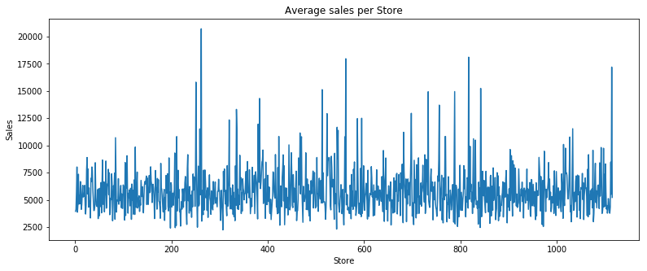

```python
#df_train.groupby('Store')[['Sales']].mean().plot figsize=(15,5), marker='o')
#df_train.Sales.max()
#df_train
#查看各店平均销售额的分布图
df_train.groupby(['Store'])['Sales'].mean().plot(figsize=(13,5))
plt.title('Average sales per Store')
plt.ylabel('Sales');
```

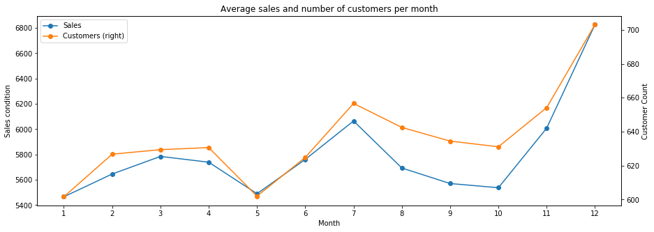

```python
#销售额和客户数平均每月分布情况
ax = df_train.groupby('Month')[['Sales', 'Customers']].mean().plot(secondary_y=['Customers'], figsize=(15,5), marker='o')
ax.set_ylabel('Sales condition')
ax.right_ax.set_ylabel('Customer Count')
ax.set_xticks(range(1,13))
plt.title('Average sales and number of customers per month');
```

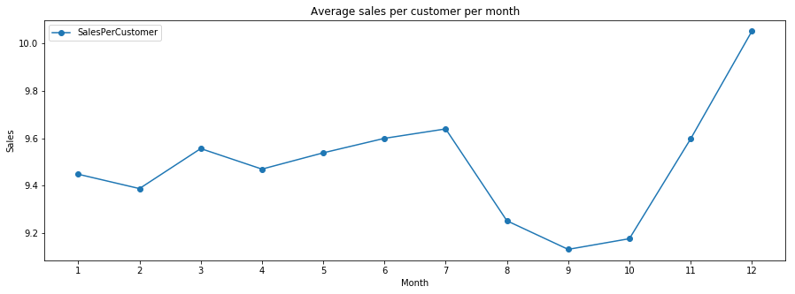

```python
# 平均每个客户每月对销售额贡献情况
ax = df_train.groupby('Month')[['SalesPerCustomer']].mean().plot(figsize=(15,5), marker='o')
ax.set_ylabel('Sales')
ax.set_xticks(range(1,13))
plt.title('Average sales per customer per month');
```

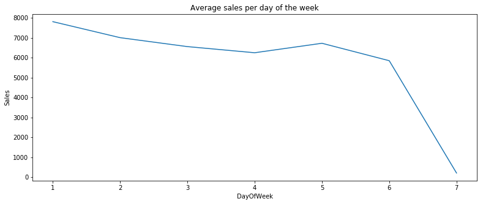

```python
#一周平均每天的销售额趋势图
df_train.groupby(['DayOfWeek'])['Sales'].mean().plot(figsize=(13,5))
plt.title('Average sales per day of the week')
plt.ylabel('Sales');
```

从上图可以看出周一整体销售情况较好，而周日的情况则相反

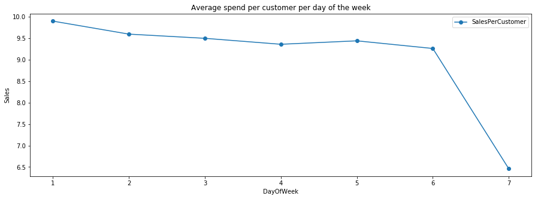

```python
ax = df_train.groupby('DayOfWeek')[['SalesPerCustomer']].mean().plot(figsize=(15,5), marker='o')
ax.set_ylabel('Sales')
plt.title('Average spend per customer per day of the week');
```

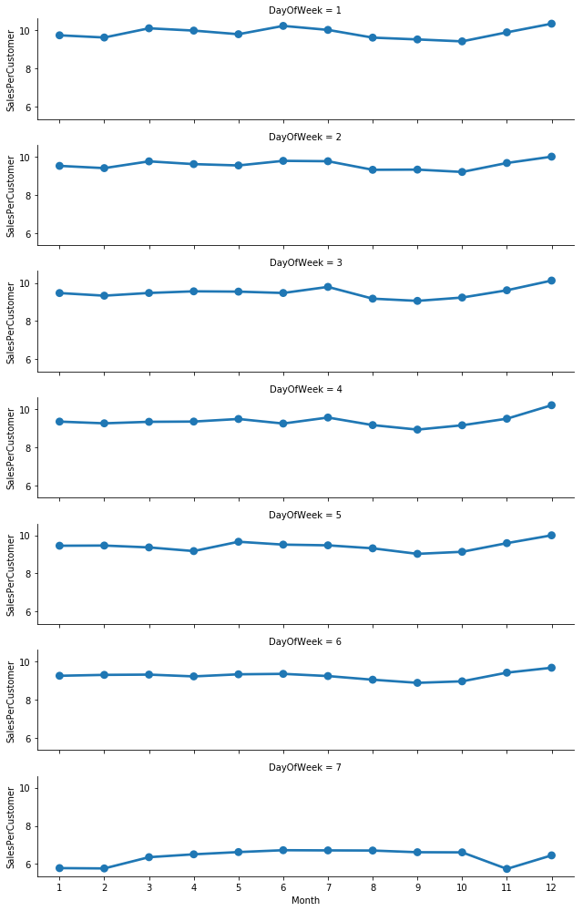

```python
tmp = df_train.groupby(['Month', 'DayOfWeek'])['SalesPerCustomer'].mean().reset_index()
sns.factorplot(data = tmp, x = 'Month', y = "SalesPerCustomer", row = 'DayOfWeek',
              size=2, aspect=4.5);
```

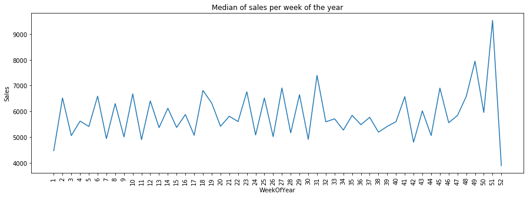

```python
df_train.groupby('WeekOfYear')['Sales'].median().plot(figsize=(15,5), xticks=np.arange(1,53), rot=90)
plt.title('Median of sales per week of the year')
plt.ylabel('Sales');#不同年每个月份平均销售情况
```

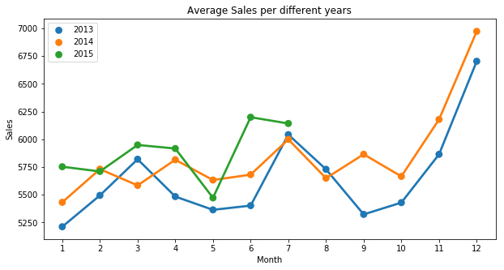

```python
#不同年每个月份平均销售情况
df_train['year']=pd.to_datetime(df_train['Date']).dt.year
df5=df_train.Sales.groupby([df_train.year,df_train.Month]).mean().reset_index()
fig=plt.figure(figsize=(10,5))
ax=fig.add_subplot(1,1,1)
sns.pointplot(x='Month',y='Sales',hue='year',data=df5,ax=ax)
ax.set_title('Average Sales per different years')
plt.legend(loc='best')
```

小结：从上面几张图中可以看出有以下情况：

- 从一周来看，周一整体销售情况较好，而周日的情况则相反
- 从一年来看，12月份的销售情况较好，而1月份的情况相反

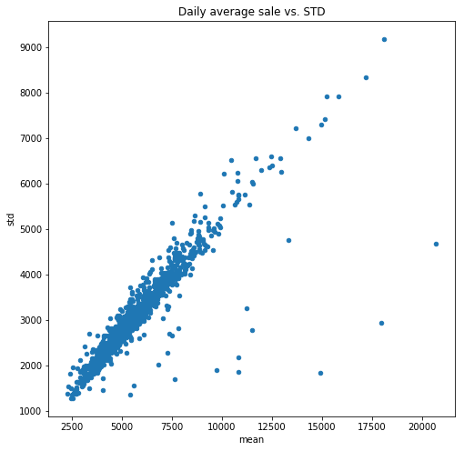

```python
tmp = df_train.groupby(['Store'])['Sales'].agg(['mean', 'std']).sort_values('mean')
tmp.plot.scatter('mean', 'std', figsize=(8,8))
plt.title('Daily average sale vs. STD');
```

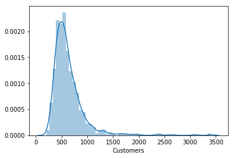

```python
sns.distplot(df_train.groupby(['Store'])['Customers'].mean())
```

[output not shown]

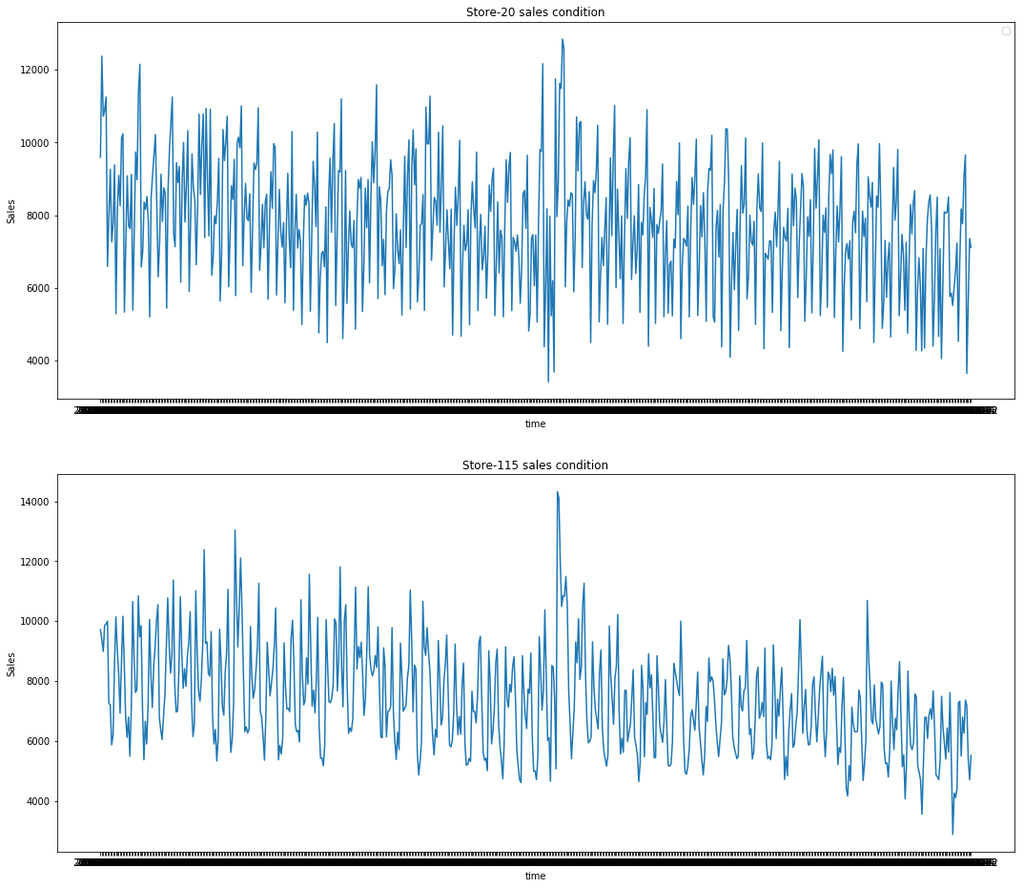

```python
#随机选取20和115号店，关注整体的销售情况
store_20 = df_train.loc[(df_train["Store"]==20)&(df_train['Sales']>0), ['Date',"Sales"]]
store_115 = df_train.loc[(df_train["Store"]==115)&(df_train['Sales']>0), ['Date',"Sales"]]
f = plt.figure(figsize=(18,16))

ax1 = f.add_subplot(211)
ax1.legend()
ax1.plot(store_20['Date'], store_20['Sales'], '-')
ax1.set_xlabel('time')
ax1.set_ylabel('Sales')
ax1.set_title('Store-20 sales condition')

ax2 = f.add_subplot(212)
ax2.plot(store_115['Date'], store_115['Sales'], '-')
ax2.set_xlabel('time')
ax2.set_ylabel('Sales')
ax2.set_title('Store-115 sales condition')
plt.show()
```

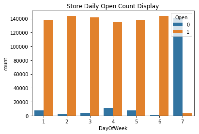

```python
#训练集中商店一周的营业和关闭的整体情况
sns.countplot(x = 'DayOfWeek', hue = 'Open', data = df_train)
plt.title('Store Daily Open Count Display')
plt.show()
```

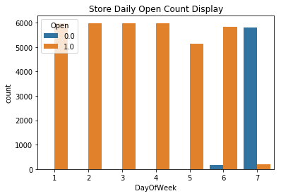

```python
#测试集中商店一周的营业和关闭的整体情况
sns.countplot(x = 'DayOfWeek', hue = 'Open', data = df_test)
plt.title('Store Daily Open Count Display')
plt.show()
```

```python
#临时连接train和store数据集
tmp_train_store = pd.merge(df_train, df_store, on='Store')
```

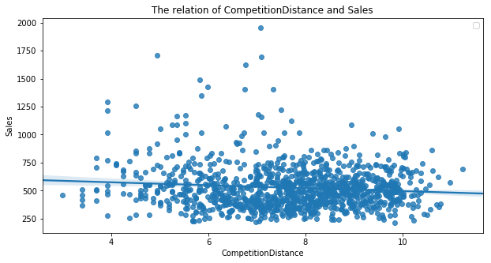

```python
tmp_train=tmp_train_store.groupby('Store')['CompetitionDistance','Sales'].agg({'CompetitionDistance':'mean','Sales':'sum'})#每个店销售总额
tmp_train['CompetitionDistance']=tmp_train['CompetitionDistance'].map(lambda x:np.log(x))#对距离取log，收缩分布
tmp_train['Sales']=tmp_train['Sales'].map(lambda x:x/10000)
fig=plt.figure(figsize=(10,5))
ax=fig.add_subplot(1,1,1)
sns.regplot(x='CompetitionDistance',y='Sales',data=tmp_train,ax=ax)
ax.set_title('The relation of CompetitionDistance and Sales')
plt.legend(loc='best')
```

上图可以简单看出，与竞争对手的店处在一定距离，销售额聚集在一个区域范围

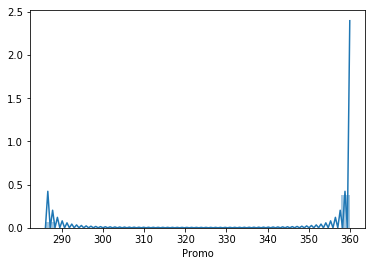

```python
#店铺促销次数比例分布
tmp_train=tmp_train_store.groupby('Store')['Promo'].sum()
fig=plt.figure()
ax=fig.add_subplot(1,1,1)
sns.distplot(tmp_train,ax=ax)
```

[output not shown]

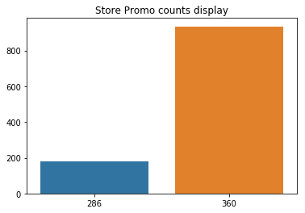

```python
tmp_train_1=tmp_train.value_counts()
fig=plt.figure()
ax=fig.add_subplot(1,1,1)
sns.barplot(tmp_train_1.index,tmp_train_1.values,ax=ax)
ax.set(**{'title':'Store Promo counts display'})
```

[output not shown]

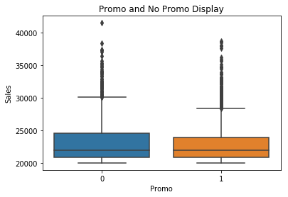

```python
fig=plt.figure()
ax=fig.add_subplot(1,1,1)
sns.boxplot(y='Sales',x='Promo',data=tmp_train_store[tmp_train_store.Sales>20000],ax=ax)
ax.set(**{'title':'Promo and No Promo Display'})
```

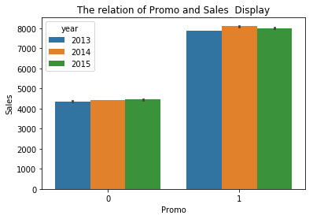

```python
#促销活动特征Promo对销售额的影响关系图
sns.barplot(x = 'Promo',y='Sales', hue = 'year', data = tmp_train_store)
plt.title('The relation of Promo and Sales  Display')
plt.show()
```

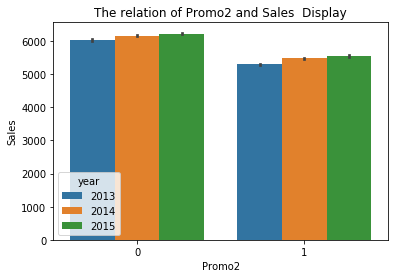

```python
#连续促销活动对销售额的影响
sns.barplot(x = 'Promo2',y='Sales', hue = 'year', data = tmp_train_store)
plt.title('The relation of Promo2 and Sales  Display')
plt.show()
```

从上面两张图可以看出：

- 促销活动确实能够提升销售额
- 但如果连续促销，则商店的销售额反而会降低。这说明长期来看，顾客的忠诚度才是销售额的关键

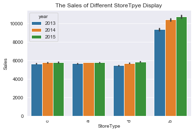

```python
#不同StoreType的销售额情况
sns.set_style("darkgrid")
bar_plot = sns.barplot(x='StoreType',y='Sales',hue='year',data = tmp_train_store)
plt.xticks(rotation=90)
plt.title('The Sales of Different StoreTpye Display')
plt.show()
```

整体来看a、c、d三种类型的商店，销售额相差不大。而b类型的商店的销售额最好

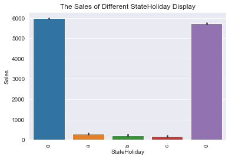

```python
#不同StateHoliday对销售额影响情况
sns.set_style("darkgrid")
bar_plot = sns.barplot(x='StateHoliday',y='Sales',data = tmp_train_store)
plt.xticks(rotation=90)
plt.title('The Sales of Different StateHoliday Display')
plt.show()
```

前面我们分析过，知道‘0’和0都为“不是假日”。因此可以看到出现州假日的情况下（无论是复活节还是圣诞节）都会对销售额产生很明显的影响

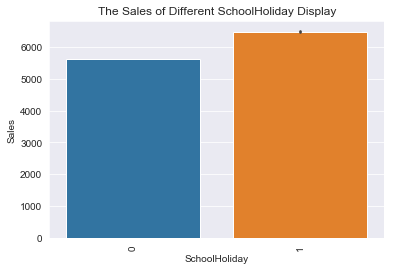

```python
#不同SchoolHoliday对销售额影响情况
sns.set_style("darkgrid")
bar_plot = sns.barplot(x='SchoolHoliday',y='Sales',data = tmp_train_store)
plt.xticks(rotation=90)
plt.title('The Sales of Different SchoolHoliday Display')
plt.show()
```

从图中可以看出，在附近学校放假的情况下对销售额有一定的提升。

```python
df_store.isnull().sum()
```

[output not shown]

```python
df_train.head().append(df_train.tail())
```

|  | Store | DayOfWeek | Date | Sales | Customers | Open | Promo | StateHoliday | SchoolHoliday | Month | WeekOfYear | SalesPerCustomer | year |
| --- | --- | --- | --- | --- | --- | --- | --- | --- | --- | --- | --- | --- | --- |
| 0 | 1 | 5 | 2015-07-31 | 5263 | 555 | 1 | 1 | 0 | 1 | 7 | 31 | 9.482883 | 2015 |
| 1 | 2 | 5 | 2015-07-31 | 6064 | 625 | 1 | 1 | 0 | 1 | 7 | 31 | 9.702400 | 2015 |
| 2 | 3 | 5 | 2015-07-31 | 8314 | 821 | 1 | 1 | 0 | 1 | 7 | 31 | 10.126675 | 2015 |
| 3 | 4 | 5 | 2015-07-31 | 13995 | 1498 | 1 | 1 | 0 | 1 | 7 | 31 | 9.342457 | 2015 |
| 4 | 5 | 5 | 2015-07-31 | 4822 | 559 | 1 | 1 | 0 | 1 | 7 | 31 | 8.626118 | 2015 |
| 1017204 | 1111 | 2 | 2013-01-01 | 0 | 0 | 0 | 0 | a | 1 | 1 | 1 | NaN | 2013 |
| 1017205 | 1112 | 2 | 2013-01-01 | 0 | 0 | 0 | 0 | a | 1 | 1 | 1 | NaN | 2013 |
| 1017206 | 1113 | 2 | 2013-01-01 | 0 | 0 | 0 | 0 | a | 1 | 1 | 1 | NaN | 2013 |
| 1017207 | 1114 | 2 | 2013-01-01 | 0 | 0 | 0 | 0 | a | 1 | 1 | 1 | NaN | 2013 |
| 1017208 | 1115 | 2 | 2013-01-01 | 0 | 0 | 0 | 0 | a | 1 | 1 | 1 | NaN | 2013 |